# SwiSca Twitter Workshop II

Steven Coats

May 2019

## Try the scripts

First we will collect tweets from the Streaming API: These are tweets broadcast in real time from Twitter’s servers.

- Navigate to your SwiSca_Workshop-master directory
- enter `python Swisca_script.py`
- You are searching for tweets containing the words *fuck*, *shit*, *bitch*, and *cunt*
- Tweets will start showing on the screen (probably too rapidly to read)
- Our script excludes retweets
- Use CTRL-X or CTRL-Z to stop the script

You can leave this script running as long as you like. The tweets are stored in the “tweetdata” folder within your SwiSca_Workshop-master folder. In “tweetdata”, each day has its own folder. Each file within the daily folder contains 500 tweets; a new file is automatically opened every 500 tweets.

## Change the search words

- Open `variables.py` in a text editor.
- Change `["fuck", "shit", "bitch", and "cunt"]` to the words you would like to find
- Save the file
- In the command shell, enter `python Swisca_script.py` again
- Use CTRL-X or CTRL-Z to stop the script

Note that for uncommon words (e.g. Nordic-language swear words), you may need to leave the script running for a long time in order to get sufficient data. This is because there are far fewer users on Twitter writing in Nordic languages, compared to English.

- If you change search parameters and want to save the results to a specific place, enter a folder name when calling the script: `python Swisca_script.py Swedish` will save the tweets to a new folder in your SwiSca_Workshop-master folder entitled “Swedish”

## Search in a particular language

- Open `Swisca_script.py` in a text editor
- Scroll down to line 69
- In the script, “comment out” the line `twitterStream.filter(track=words)` by adding “#” before it
- “Uncomment” the next line by deleting the “#”
- Save the file and run the script again
- Now you are looking for the same words, but only in tweets that have been automatically identified to be in Swedish, Fininsh, Norwegian, or Danish
- Again, it may take a while to get a lot of data

## Search in a particular place

- To search for tweets from a place, you can define the “bounding box” of latitude-longitude coordinates that contain that place
- In `Swisca_script.py`, uncomment line 68 by deleting “#” from `#twitterStream.filter(locations = [19,59,32,70], stall_warning = True)`, and comment lines 69 and 70
- Save the script and run it again
- Now we are getting tweets from within the box formed by (longitude:19,latitude:59,longitude:32,latitude:70)
- This defines a box approximately around Finland

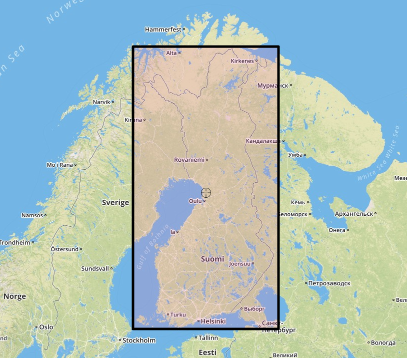

- You should start seeing tweets in Finnish and Russian (among other languages)
- Note that this method only gets tweets from people who have turned on the “Tweet location” option in their settings (most users have not)
- You can check the coordinates of boxes at [bboxfinder](http://bboxfinder.com)
- An additional filtering step can be used to get tweets in a specific language

## Use Twarc

[Twarc](https://github.com/DocNow/twarc) is another Python library for interacting with Twitter APIs. We will use it to get data from the REST API. Instead of getting a sample of tweets in real time as they are being broadcast, we search Twitter’s archive and collect tweets that contain a term of interest that have been broadcast within the last 7 days.

- enter `twarc configure`
- You will be prompted to input your access tokens. Follow the instructions
- enter `python twarc-archive.py --tweet_mode="extended" "helvete OR förbannat OR förbannade OR jävla" tweetdata`
- The script will download the relevant tweets to a file `tweets-0001.jsonl.gz` in the “tweetdata” directory
- Calls to Twitter's REST API are rate-limited, so if your query returns many results, the script will automatically wait in order to retrieve remaining hits
- You can automate this script to run at regular intervals (e.g. once a day, using crontab in Linux or Task Scheduler in Windows): duplicate tweets will be automatically excluded, and any new ones containing your words will be collected
- To collect to a specifc folder, specify the destination argument, e.g. `python twarc-archive.py --tweet_mode="extended" "vittu OR vitun OR vitusta" /tweetdata/Finnish`
- To get a specific language, try this: `twarc search 'bitch' --lang sv > tweetdata/bitch_sv.jsonl`

## Make a map

- Run `python SwiSca_vis.py`
- You see the locations of tweets with geographical metadata that contain the words in `variables.py`
- Visualize different words by changing `variables.py`
- Specify a folder to visualize only the tweets therein: `python SwiSca_vis.py Finnish`

[interactive chart not shown]

## Get the texts

- Run `python SwiSca_text.py`
- This outputs to a csv file with the fields “screen_name”, “country” (if any), and “text”